# **第四章：聚类分析**

#### 4.7.3.9 Spatial Plot of the Clustering Result - 聚类结果的空间图

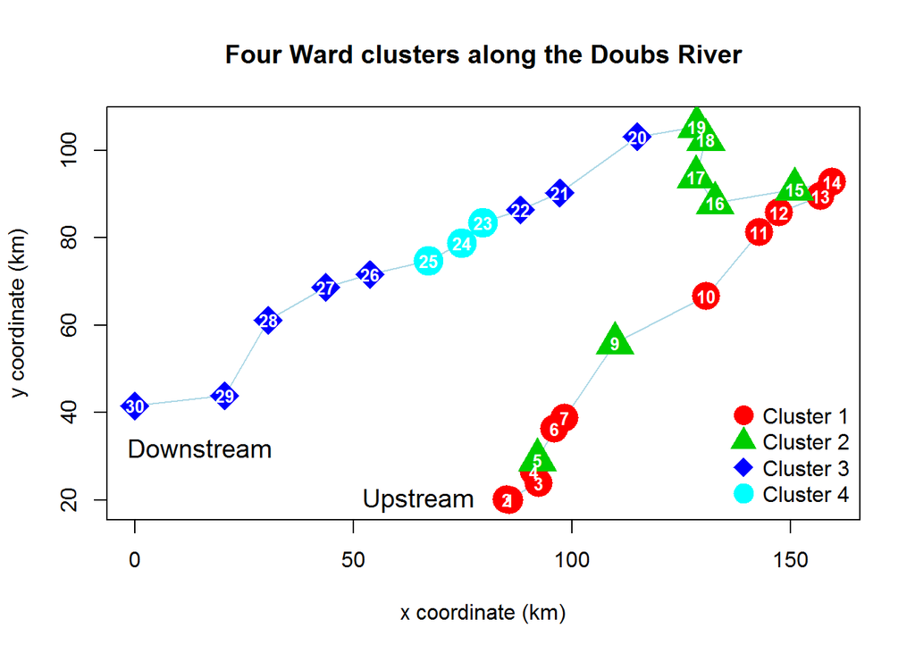

```r
# 将 ward 最小方差聚类分析的结果通过地图的形式呈现
# dim(spa)
# [1] 29  2
drawmap(xy = spa, # 地理位置数据集 - 经纬度
        clusters = spech.ward.g, # ward 最小方差聚类分析的结果对象
        main = "Four Ward clusters along the Doubs River")
```

#### 4.7.3.10 Heat Map and Ordered Community Table - 热图和有序群落表

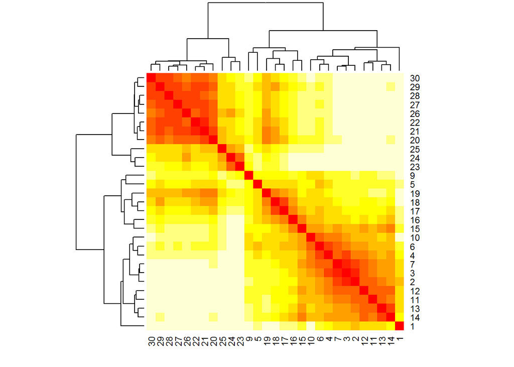

```r
# 绘制排序后的树形图的相异矩阵的热图
heatmap(
  as.matrix(spe.ch),
  Rowv = dend, # 确定是否以及如何计算和重新排序 - 行 - 树形图
  symm = TRUE, # 是否对数据进行对称处理
  margin = c(3, 3) # 设置行列名的边距
  )
```

最后, 根据组成员关系重新排序原始数据表并探究分类簇中物种含量可能会有不一样的发现.

使用 vegan 分析包中的 vegemite() 函数避免大值在绘图过程中造成的堵塞影响, 该函数使用外部数据重排和展示’物种-位点’数据表, 其中丰度值使用不同的方法进行了重排. 如果没有物种的特定排序, 则通过位点分数上的加权平均值进行排序. vegemite() 函数所接受的丰度尺度为个位数(0 ~ 9), >= 10 的数字将无法运行该函数.

```r
# 排序后的群落表
# 通过位点分数的加权平均数重新排序物种
# 点 - 不存在
# https://www.rdocumentation.org/packages/vegan/versions/2.4-2/topics/vegemite
# vegemite() & tabasco() 展示紧凑的群落表
or <- vegemite(spe, spe.chwo)
```

```
##
##       32222222222  111111     1111
##       09876210543959876506473221341
##  Icme 5432121......................
##  Abbr 54332431.....1...............
##  Blbj 54542432.1...1...............
##  Anan 54432222.....111.............
##  Gyce 5555443212...11..............
##  Scer 522112221...21...............
##  Cyca 53421321.....1111............
##  Rham 55432333.....221.............
##  Legi 35432322.1...1111............
##  Alal 55555555352..322.............
##  Chna 12111322.1...211.............
##  Titi 53453444...1321111.21........
##  Ruru 55554555121455221..1.........
##  Albi 53111123.....2341............
##  Baba 35342544.....23322.........1.
##  Eslu 453423321...41111..12.1....1.
##  Gogo 5544355421..242122111......1.
##  Pefl 54211432....41321..12........
##  Pato 2211.222.....3344............
##  Sqce 3443242312152132232211..11.1.
##  Lele 332213221...52235321.1.......
##  Babl .1111112...32534554555534124.
##  Teso .1...........11254........23.
##  Phph .1....11...13334344454544455.
##  Cogo ..............1123......2123.
##  Satr .1..........2.123413455553553
##  Thth .1............11.2......2134.
##   sites species
##      29      27
```

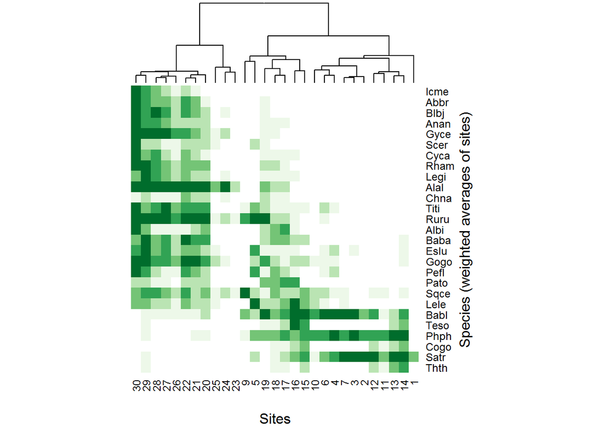

```r
# 带有树形图的双序群落列表的热图
heatmap(
  t(spe[rev(or$species)]), # 转置数据
  Rowv = NA, # 禁止任何行树形图（和重新排序）
  Colv = dend, # 确定是否以及如何重新排序 - 列 - 树形图
  col = c("white", brewer.pal(5, "Greens")),
  scale = "none", # 值应该在行方向或列方向上居中和缩放; 默认 - 行
  margin = c(4, 4), # 设置行列名的边距
  ylab = "Species (weighted averages of sites)",
  xlab = "Sites")
```

## 4.8 Non-hierarchical Clustering - 非层次聚类

非层次聚类是对一系列对象进行简单分区(分组). 也可以这样进行表述: 将 p-维空间中的 n 个对象划分成 k 个组(簇), 使得每个簇中的对象更加相近. 分成的组个数(簇个数)可根据需要随意设置.

非层次聚类的算法归根到底是一种**迭代**方法, 首先需要将所有的对象分成 k 组作为分析的初始结构, 然后通过迭代的方式选择最优的结果.

用户可以根据需要随意设置最初的分组数量(如果不进行修改, 则采用系统默认值). 通过不同的随机初始值进行多次分析, 以期获得最优的解决方案.

本章将介绍两种相类似的方法: k-means 划分方法(k-均值聚类) 和 围绕中心点划分(partitioning around medoids, PAM). **这两种方法的限定场景是’Euclidean space’.**

这里需要注意的是, 如果数据表(群落数据)中的变量不具有维度均质化, 则必须在划分处理之前进行数据标准化. 否则数据的总方差具有维度属性(各个变量的平方维度和)则是无意义的.

### 4.8.1 k-means Partitioning - k-均值分配

k-均值划分的方法使用局部数据来确定分类簇: 通过识别鉴定数据中的高密度区域来形成分类簇. 为实现这一目的, 该方法需要通过迭代最小化’总平方和误差(TESS or SSE, 组内平方和的和)’目标函数. *这个值是建立在所有 k 个分类组上的, 分类组中的所有对象的平方(Euclidean)距离的和, 每个值都除以分类组中的对象数量.* 这和 Ward 最小方差聚合聚类分析使用的标准一样.

#### 4.8.1.1 k-means with Random Starts - 随机化的 k-均值

如果考虑到预先分组的数量, 可以使用 stats 分析包中的 kmeans() 函数. 该函数可使用不同的随机初始值, 自动地重复大量(次数由参数 nstart 决定)的分析, 经过多次(次数由 nstart 决定)重复分析之后找到最优的解决方案(最小化的 SSE 值, 也就是最小的’总平方和误差’)

k-均值分区方法是一种线性分析方法, 并不适合分析含有大量零值的原始物种丰度数据.

(**第一种解决方案**)一种可能性是使用’非欧式相异矩阵(non-Euclidean dissimilarity matrices)’, 比如百分比差异( Bray-Curtis ); 这一类的矩阵应该进行平方化数值转换, 为能够获得对象在’欧式空间(Euclidean space)’中的所有表示, 需要将数值转换之后的数据进行主坐标分析(principal coordinate analysis, PCoA). 将获得的 PCOA 轴 进行 k-均值分区处理.

(**第二种解决方案**)另一种解决方案需要对物种数据进行预转换(对物种数据进行弦转换或者标准化, chord-transformed 或 ‘normalized’). 当与 k-均值中隐含的欧式距离相结合时, 在后续的分析过程中需要保留位点之间的弦距离.

为了与上述 ward 最小方差聚类结果进行比较, 下文将 k 设置为 4 进行 k-均值聚类分析.

```r
# K均值分解的物种数据预转换
# 由于 'nstart' 起始于不同的随机配置, 因此每次运行的结果可能会有所不一样
spe.kmeans <- kmeans(spe.norm, # 数据标准化转换
                     centers = 4, # 分成 4 个簇类
                     nstart = 100) # 如果 centers 是整数,应该选取多少个随机数据集
head(spe.kmeans)
```

```
## $cluster
##  1  2  3  4  5  6  7  9 10 11 12 13 14 15 16 17 18 19 20 21 22 23 24 25 26
##  3  3  3  3  2  3  3  2  3  3  3  3  3  3  2  2  2  2  1  1  1  4  4  4  1
## 27 28 29 30
##  1  1  1  1
##
## $centers
##         Cogo        Satr       Phph       Babl        Thth        Teso
## 1 0.00000000 0.006691097 0.02506109 0.06987391 0.006691097 0.006691097
## 2 0.06167791 0.122088022 0.26993915 0.35942538 0.032664966 0.135403325
## 3 0.10380209 0.542300691 0.50086515 0.43325916 0.114024105 0.075651573
## 4 0.00000000 0.000000000 0.00000000 0.00000000 0.000000000 0.000000000
##         Chna       Pato       Lele      Sqce       Baba      Albi
## 1 0.10687104 0.09377516 0.14194394 0.2011411 0.24327992 0.1326062
## 2 0.06212775 0.21568957 0.25887226 0.2722562 0.15647062 0.1574388
## 3 0.00000000 0.00000000 0.06983991 0.1237394 0.02385019 0.0000000
## 4 0.05205792 0.00000000 0.07647191 0.3166705 0.00000000 0.0000000
##         Gogo       Eslu       Pefl      Rham       Legi       Scer
## 1 0.28386032 0.20630360 0.16920496 0.2214275 0.19066542 0.13171275
## 2 0.16822286 0.12276089 0.17261621 0.0793181 0.06190283 0.04516042
## 3 0.05670453 0.04722294 0.02949244 0.0000000 0.00000000 0.00000000
## 4 0.20500174 0.07647191 0.00000000 0.0000000 0.05205792 0.07647191
##         Cyca       Titi       Abbr      Icme       Gyce       Ruru
## 1 0.16019126 0.26230024 0.19561641 0.1331835 0.26713081 0.32103755
## 2 0.06190283 0.14539027 0.01473139 0.0000000 0.03192175 0.32201597
## 3 0.00000000 0.03833408 0.00000000 0.0000000 0.00000000 0.01049901
## 4 0.00000000 0.00000000 0.00000000 0.0000000 0.18058775 0.31667052
##         Blbj      Alal       Anan
## 1 0.22883055 0.3326939 0.18873077
## 2 0.01473139 0.1095241 0.04739636
## 3 0.00000000 0.0000000 0.00000000
## 4 0.05205792 0.7618709 0.00000000
##
## $totss
## [1] 15.24268
##
## $withinss
## [1] 0.4696535 1.7361453 2.5101386 0.3560423
##
## $tot.withinss
## [1] 5.07198
##
## $betweenss
## [1] 10.17071
```

```r
# 通过列联表进行比较分析 | 比较聚类结果是否相似
# 使用交叉分类因子来构建每个因子水平组合的计数的列联表
table(spe.kmeans$cluster, # k-均值 簇类向量
      spech.ward.g) # ward 最小方差聚类分析 簇类向量
```

```
##    spech.ward.g
##      1  2  3  4
##   1  0  0  8  0
##   2  0  6  0  0
##   3 11  1  0  0
##   4  0  0  0  3
```

(*上文中的’第一种解决方案’*) 对于不能从原始数据转换后进行欧式距离(Euclidean distance)计算的相异指数(如 百分比差异相异矩阵, Bray-Curtis), 需要先将原始数据相异度矩阵进行主坐标分析(principal coordinate analysis, PCoA)以获得 n 行的数据表格, 然对获得的数据表格进行 k-均值聚类分析. 对于百分比差异的相异矩阵(Bray-Curtis 相异矩阵), 首先需要对其平方根化然后在进行 PCoA 分析以获得完全的欧式解决方案, 或者使用提供负特征值校对的 PCoA 函数进行分析.

划分区处理可产生一个具有预定义的分组数量的简单分区. 可以通过尝试不同的分组数量进行多次重复分析.

只有首先确定’最好聚类方案的选择标准’, 才能选出’多少分组(聚类簇)数量才是最好’. (*磨刀不误砍柴工*)

可以使用cclust 分析包中的 clustIndex() 函数获得多种聚类簇选择的标准. 1) Calinski 指数: 比较组间和组内分区的平方和 (由于聚类簇内所含对象数量的不一致性或者说是差异较大, 导致 Calinski 指数可能会比较低); 2) SSI (Simple Structure Index), 简单结构指数的最大值也是衡量最小二乘意义下的最优分区结果的选择标准.

使用 vegan 分析包中的 cascadeKM() 函数, 可以避免多次简单调用 kmeans() 的繁琐操作, 同时该函数也是 kmeans() 函数功能的升级应用(可以实现一定聚类簇数量范围之内的重复调用 kmeams ).

```r
# k-均值划分 2 ~ 10 簇类
# cascadeKM 是 vegan 分析包中的 函数
# 使用一系列的 k 值进行k-均值划分; 并提供一定的数值统计
# https://www.rdocumentation.org/packages/vegan/versions/2.4-2/topics/cascadeKM
spe.KM.cascade <- cascadeKM(spe.norm,
                              inf.gr = 2, # 最小分区数值
                              sup.gr = 10, # 最大分区数值
                              iter = 100, # 随机数起始的配指数
                              criterion = "ssi") # 用于选择最佳分区的标准参考 | ssi - 简单的结构索引
summary(spe.KM.cascade)
```

```
##           Length Class  Mode
## partition 261    -none- numeric
## results    18    -none- numeric
## criterion   1    -none- character
## size       90    -none- numeric
```

```r
head(spe.KM.cascade$results)
```

```
##      2 groups  3 groups  4 groups   5 groups   6 groups  7 groups
## SSE 8.2149405 6.4768108 5.0719796 4.30155732 3.58561200 2.9523667
## ssi 0.1312111 0.1685126 0.1409496 0.08442032 0.06034905 0.1088769
##       8 groups  9 groups  10 groups
## SSE 2.48405487 2.0521888 1.75992916
## ssi 0.07555728 0.1067758 0.07094594
```

```r
head(spe.KM.cascade$partition)
```

```
##   2 groups 3 groups 4 groups 5 groups 6 groups 7 groups 8 groups 9 groups
## 1        2        1        3        4        2        3        1        5
## 2        2        1        3        5        6        5        6        4
## 3        2        1        3        5        6        5        6        4
## 4        2        1        3        5        6        5        6        4
## 5        1        3        2        2        4        1        5        3
## 6        2        1        3        5        6        5        6        4
##   10 groups
## 1         1
## 2         3
## 3         3
## 4         3
## 5         4
## 6         5
```

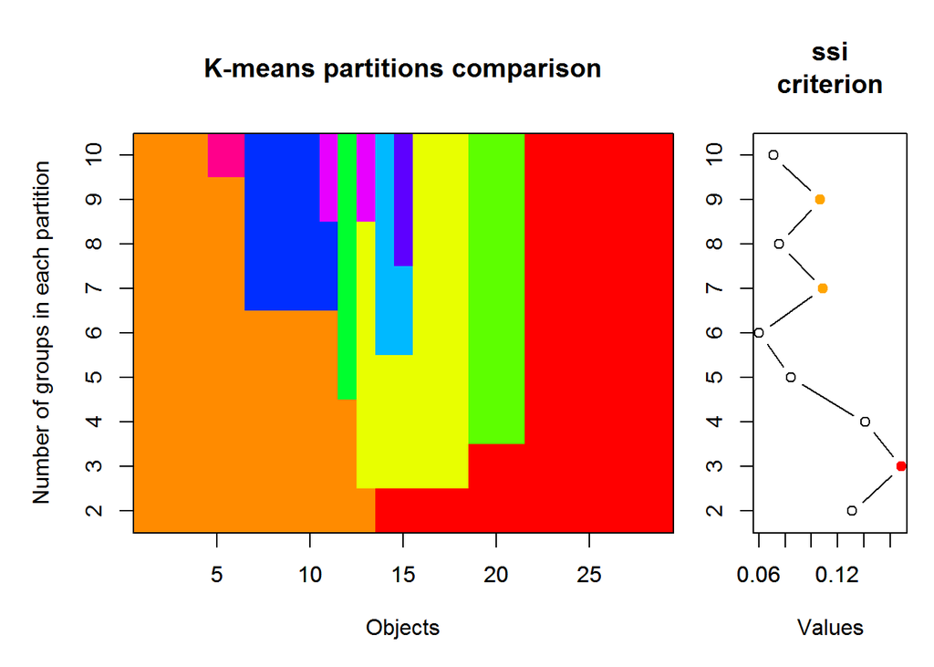

```r
plot(spe.KM.cascade,
     sortg = T) # 是否对簇类进行排序 | 按照紧密程度重新进行排序
```

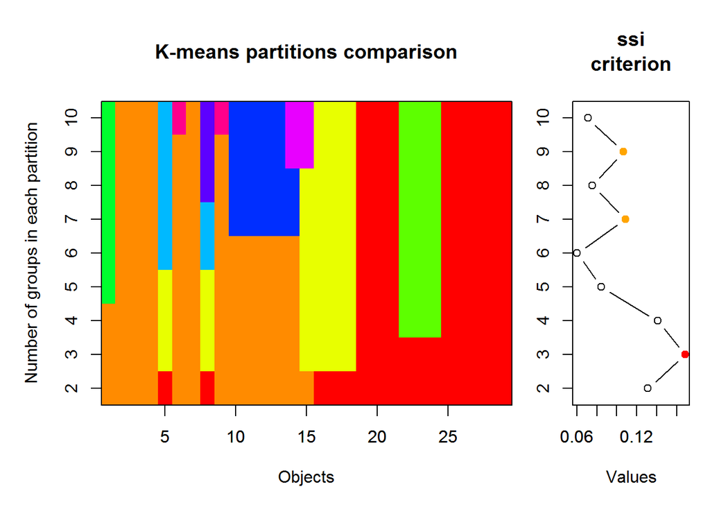

```r
plot(spe.KM.cascade,
     sortg = F) # 是否对簇类进行排序 | 不按照紧密程度重新进行排序
```

```r
plot(spe.KM.cascade) # 使用默认参数

# 注意比较分类之间的不同之处
# 通过列联表进行比较分析
# 使用交叉分类因子来构建每个因子水平组合的计数的列联表
table(spe.kmeans$cluster, # k-均值 簇类向量
      spech.ward.g) # ward 最小方差聚类分析 簇类向量
```

```
##    spech.ward.g
##      1  2  3  4
##   1  0  0  8  0
##   2  0  6  0  0
##   3 11  1  0  0
##   4  0  0  0  3
```

```r
# 通过列联表进行比较分析
# 使用交叉分类因子来构建每个因子水平组合的计数的列联表
table(spe.KM.cascade$partition[, 3], # k-均值 划分 3 个簇类之后的 簇类向量
      spech.ward.g) # ward 最小方差聚类分析 簇类向量
```

```
##    spech.ward.g
##      1  2  3  4
##   1  0  0  8  0
##   2  0  6  0  0
##   3 11  1  0  0
##   4  0  0  0  3
```

```r
# 根据 k-均值 对位点数据进行重排序
spe.kmeans.g <- spe.kmeans$cluster
class(spe.kmeans.g) # 查看类别信息
```

```
## [1] "integer"
```

```r
head(spe[order(spe.kmeans.g), ])
```

```
##    Cogo Satr Phph Babl Thth Teso Chna Pato Lele Sqce Baba Albi Gogo Eslu
## 20    0    0    1    2    0    0    2    2    2    3    4    3    4    2
## 21    0    0    1    1    0    0    2    2    2    2    4    2    5    3
## 22    0    0    0    1    0    0    3    2    3    4    5    1    5    3
## 26    0    0    0    1    0    0    1    0    1    2    2    1    3    2
## 27    0    0    0    1    0    0    1    1    2    3    4    1    4    4
## 28    0    0    0    1    0    0    1    1    2    4    3    1    4    3
##    Pefl Rham Legi Scer Cyca Titi Abbr Icme Gyce Ruru Blbj Alal Anan
## 20    2    3    2    2    1    4    1    0    2    5    2    5    2
## 21    3    3    2    2    2    4    3    1    3    5    3    5    2
## 22    4    3    3    2    3    4    4    2    4    5    4    5    2
## 26    1    2    2    1    1    3    2    1    4    4    2    5    2
## 27    1    3    3    1    2    5    3    2    5    5    4    5    3
## 28    2    4    4    2    4    4    3    3    5    5    5    5    4
```

```r
# 重新排序位点和物种信息
# 显示紧凑有序的社区表
ord.KM <- vegemite(spe, # 物种原始数据集
                   spe.kmeans.g)  # k-均值聚类分析的结果对象
```

```
##
##       22222223  1111      111111222
##       01267890596789123467012345345
##  Icme .1212345.....................
##  Abbr 13423345.....1...............
##  Anan 22223445...111...............
##  Blbj 23424545.....1.............1.
##  Rham 33323455...122...............
##  Cyca 12312435..1111...............
##  Legi 22323453..1111.............1.
##  Scer 222112252....1..............1
##  Gyce 23445555....11.............21
##  Albi 32111135..1432...............
##  Baba 44524353..2332..........12...
##  Titi 44435435311112...12......1...
##  Chna 22311121...112.............1.
##  Pefl 234112454.1231...21..........
##  Ruru 55545555541225....1.......121
##  Eslu 233243544.1111..121.....1...1
##  Pato 222.1122..4433...............
##  Gogo 455344552.2124...11.1...12.12
##  Alal 55555555...223............253
##  Lele 223122335.5322....112....3..1
##  Sqce 32423443252231...121211.13121
##  Teso ......1...5211.........234...
##  Babl 2111111.235435.35555414245...
##  Phph 11....1.313433.45544444554...
##  Cogo ..........211........12233...
##  Thth ......1....11........12342...
##  Satr ......1.2.321.355435135554...
##   sites species
##      29      27
```

```r
head(spe[ord.KM$sites, ord.KM$species])
```

```
##    Icme Abbr Anan Blbj Rham Cyca Legi Scer Gyce Albi Baba Titi Chna Pefl
## 20    0    1    2    2    3    1    2    2    2    3    4    4    2    2
## 21    1    3    2    3    3    2    2    2    3    2    4    4    2    3
## 22    2    4    2    4    3    3    3    2    4    1    5    4    3    4
## 26    1    2    2    2    2    1    2    1    4    1    2    3    1    1
## 27    2    3    3    4    3    2    3    1    5    1    4    5    1    1
## 28    3    3    4    5    4    4    4    2    5    1    3    4    1    2
##    Ruru Eslu Pato Gogo Alal Lele Sqce Teso Babl Phph Cogo Thth Satr
## 20    5    2    2    4    5    2    3    0    2    1    0    0    0
## 21    5    3    2    5    5    2    2    0    1    1    0    0    0
## 22    5    3    2    5    5    3    4    0    1    0    0    0    0
## 26    4    2    0    3    5    1    2    0    1    0    0    0    0
## 27    5    4    1    4    5    2    3    0    1    0    0    0    0
## 28    5    3    1    4    5    2    4    0    1    0    0    0    0
```

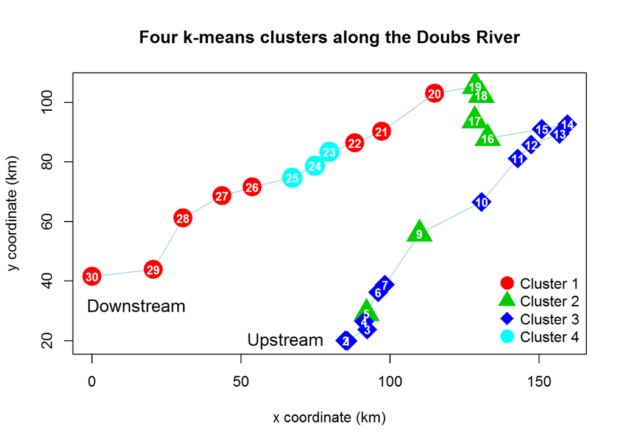

```r
# 聚类分析的结果通过地图的形式呈现
drawmap(xy = spa, # 原始地理位点信息 - 经纬度
        clusters = spe.kmeans.g, # 聚类分析结果的对象
        main = "Four k-means clusters along the Doubs River")
```

#### 4.8.1.2 Use of k-means Partitioning to Optimize an Independently Obtained Classification - 使用 k-均值分配方法优化已独立获得的分类结果

从另一种角度来看, k-均值聚类分析可被用来优化层次聚类结果. 事实上, 聚合算法本质上组织了组内对象向后续聚合分析新产生组的转移, 即便后续聚合分析的结果更加适合. 为了克服这个潜在的问题, 我们可以向k-均值算法提供从要优化的聚类中得到的先验信息, 要么是以用该方法获得的 k 个组中 p 个变量均值的 k*p 矩阵的形式, 要么是以 k 个对象的列表的形式; 每组生成一个’典型’对象.

在后面的一节中, 这种’典型’对象被称为’中心点划分’, 视为用于构建群体的种子. 使用该方法验证鱼类物种数据经过 ward 最小方差聚类分析获得的 4 个分组是否经过了 k-均值聚类分析的调整.

```r
# 位点数据 - ward 最小方差聚类分析中的 平均物种丰度
groups <- as.factor(spech.ward.g) # 弦距离矩阵 - ward 聚类分析 - 簇类向量 因子化
spe.means <- matrix(0, ncol(spe), length(levels(groups))) # 全 0 矩阵
row.names(spe.means) <- colnames(spe)
# tapply - 将函数应用于不规则数组的每个单元格
# 进行分组统计 - tapply(x,f,g)
# x为向量,f为因子列,g为操作函数,相对数据框进行类似操作可以用by函数
for (i in 1:ncol(spe)) {
  spe.means[i, ] <- tapply(spe.norm[, i],  # spe.norm 物种数据标准化变换
                           spech.ward.g,
                           mean)
  }

startpoints <- t(spe.means) # 平均物种丰度作为起始点
# k-means on starting points - 对起始点进行 k-均值 聚类分析
spe.kmeans2 <- kmeans(spe.norm,
                      centers = startpoints) # 注意: 非整数分区 | 矩阵

startobjects <- spe.norm[c(2, 17, 21, 23), ] # 起始对象
spe.kmeans3 <- kmeans(spe.norm,
                      centers = startobjects) # 注意: 非整数分区 | 矩阵

# 通过列联表进行比较分析
# 使用交叉分类因子来构建每个因子水平组合的计数的列联表
table(spe.kmeans2$cluster, # 根据起始位点进行 k-均值聚类分析 簇类向量
      spech.ward.g) # 物种数据集 - 弦距离矩阵 - ward 聚类分析 - 簇类向量
```

```
##    spech.ward.g
##      1  2  3  4
##   1 11  1  0  0
##   2  0  6  0  0
##   3  0  0  8  0
##   4  0  0  0  3
```

```r
# 通过列联表进行比较分析
# 使用交叉分类因子来构建每个因子水平组合的计数的列联表
table(spe.kmeans2$cluster, # 根据起始位点进行 k-均值聚类分析 簇类向量
      spe.kmeans3$cluster) # 根据起始对象进行 k-均值聚类分析 簇类向量
```

```
##
##      1  2  3  4
##   1 12  0  0  0
##   2  0  6  0  0
##   3  0  0  8  0
##   4  0  0  0  3
```

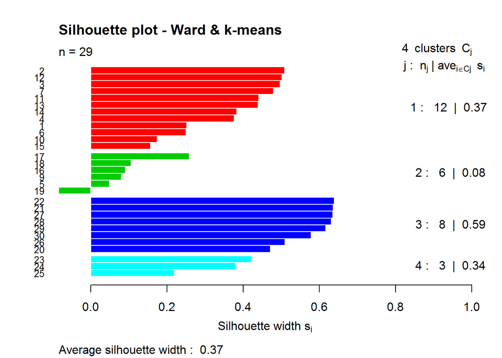

```r
# 系列 k-均值 聚类分析的 簇类向量
spech.ward.gk <- spe.kmeans2$cluster
k <- 4
# 应用 silhouette 提取轮廓信息
sil <- silhouette(spech.ward.gk, # 系列 k-均值 聚类分析的 簇类向量
                  spe.ch) # 物种数据集的弦距离矩阵
rownames(sil) <- row.names(spe)
plot(sil,
     main = "Silhouette plot - Ward & k-means",
     cex.names = 0.8,
     col = 2:(k + 1))
```

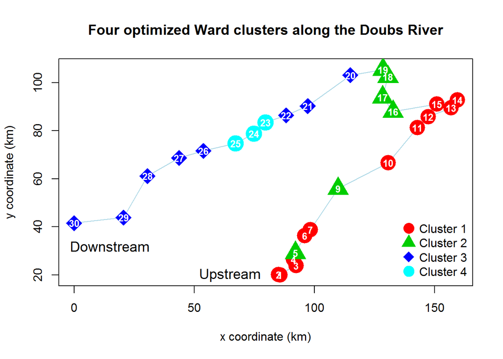

```r
drawmap(xy = spa, # 原始地理位点信息 - 经纬度
       clusters = spech.ward.gk, # 聚类分析结果的对象
       main = "Four optimized Ward clusters along the Doubs River")
```

### 4.8.2 Partitioning Around Medoids (PAM) - 分区围绕中心点（围绕中心点划分）

**“在数据集的观测值中筛选 k 个具有代表性的对象或中心点. 这些观测值应该代表数据集的结构. 在确定一系列 k 个中心点之后, 通过将每个观察值分配(制定)给最近的中心点来构建聚类簇. 这一系列操作的目的在于找到 k 个代表性的对象, 并且这些代表性对象可以最小化观察值与其最近代表性对象的相异之和”** – pam() 函数描述

与之不同的是, k-均值聚类分析中最小化的是组内欧式距离的平方和, 因此, k-均值聚类是纯铜的最小二乘方法, 然而, **PAM 并不是最小二乘方法**.

cluster 分析包中的 pam() 函数既可以输入原始数据, 也可以输入相异矩阵; 然而, kmeans() 函数只能输入变换之后的数据矩阵; 同时, pan() 函数可允许通过轮廓宽度准则来选择最优的分组数量.

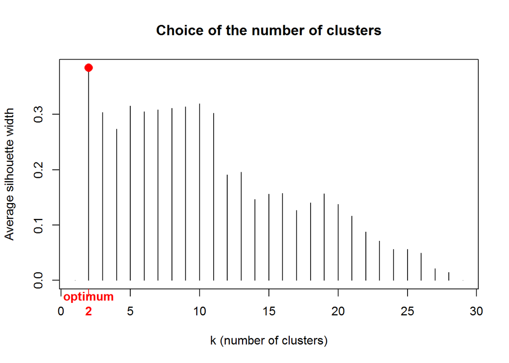

```r
# 使用 物种弦距离矩阵 选择簇类数量
asw <- numeric(nrow(spe)) # 生成 nrow(spe) 数值化的向量
for (k in 2:(nrow(spe) - 1)) {
  # 围绕中心点划分
  asw[k] <- pam(spe.ch, k, diss = TRUE)$silinfo$avg.width
  }
k.best <- which.max(asw)
plot(
  1:nrow(spe),
  asw,
  type = "h", # 垂直线
  main = "Choice of the number of clusters",
  xlab = "k (number of clusters)",
  ylab = "Average silhouette width" )
axis(
  1, # 哪一侧绘制轴: 1 下; 2 左; 3 上; 4 右
  k.best, # 轴上的位置
  paste("optimum", k.best, sep = "\n"),
  col = "red",
  font = 2,
  col.axis = "red")
points(k.best, # X 轴位置
       max(asw), # Y 轴位置
       pch = 16,
       col = "red",
       cex = 1.5)
```

```r
spe.ch.pam <- pam(spe.ch, k = 4, diss = TRUE) # 围绕中心点划分
summary(spe.ch.pam)
```

```
## Medoids:
##      ID
## [1,] "11" "12"
## [2,] "6"  "6"
## [3,] "16" "17"
## [4,] "25" "26"
## Clustering vector:
##  1  2  3  4  5  6  7  9 10 11 12 13 14 15 16 17 18 19 20 21 22 23 24 25 26
##  1  1  1  2  2  2  1  2  2  1  1  1  1  1  3  3  3  3  4  4  4  4  4  4  4
## 27 28 29 30
##  4  4  4  4
## Objective function:
##     build      swap
## 0.4426460 0.4390712
##
## Numerical information per cluster:
##      size  max_diss   av_diss  diameter separation
## [1,]    9 0.8769750 0.4350972 1.1168811  0.3429386
## [2,]    5 0.8814766 0.4962134 1.0854578  0.3429386
## [3,]    4 0.5988903 0.3678822 0.8037373  0.4977122
## [4,]   11 0.8841837 0.4422357 1.1276080  0.4977122
##
## Isolated clusters:
##  L-clusters: character(0)
##  L*-clusters: character(0)
##
## Silhouette plot information:
##    cluster neighbor   sil_width
## 13       1        2  0.42988827
## 12       1        2  0.40576079
## 2        1        2  0.38341138
## 14       1        2  0.35676210
## 11       1        2  0.34188972
## 3        1        2  0.27044354
## 1        1        2  0.24590101
## 7        1        2  0.24135661
## 15       1        3  0.05061851
## 6        2        1  0.09343621
## 10       2        1  0.06179173
## 9        2        3  0.04916887
```

[output cut: 10 more lines]

```
## 21       4        3  0.39375977
## 29       4        3  0.36426967
## 30       4        3  0.36420744
## 24       4        3  0.31070288
## 25       4        3  0.26599024
## 20       4        3  0.23649622
## 23       4        3  0.21029600
## Average silhouette width per cluster:
## [1] 0.302892439 0.003827211 0.306962948 0.360150134
## Average silhouette width of total data set:
## [1] 0.2736094
##
## Available components:
## [1] "medoids"    "id.med"     "clustering" "objective"  "isolation"
## [6] "clusinfo"   "silinfo"    "diss"       "call"
```

```r
spe.ch.pam.g <- spe.ch.pam$clustering
head(spe.ch.pam$silinfo$widths) # 轮廓宽度
```

```
##    cluster neighbor sil_width
## 13       1        2 0.4298883
## 12       1        2 0.4057608
## 2        1        2 0.3834114
## 14       1        2 0.3567621
## 11       1        2 0.3418897
## 3        1        2 0.2704435
```

```r
# 通过列联表进行比较分析
# 使用交叉分类因子来构建每个因子水平组合的计数的列联表
table(spe.ch.pam.g,
      spech.ward.g)
```

```
##             spech.ward.g
## spe.ch.pam.g 1 2 3 4
##            1 8 1 0 0
##            2 3 2 0 0
##            3 0 4 0 0
##            4 0 0 8 3
```

```r
# 通过列联表进行比较分析
# 使用交叉分类因子来构建每个因子水平组合的计数的列联表
table(spe.ch.pam.g,
      spe.kmeans.g)
```

```
##             spe.kmeans.g
## spe.ch.pam.g 1 2 3 4
##            1 0 0 9 0
##            2 0 2 3 0
##            3 0 4 0 0
##            4 8 0 0 3
```

```r
# 通过列联表进行比较分析
# 使用交叉分类因子来构建每个因子水平组合的计数的列联表
table(spe.kmeans.g,
      spech.ward.gk)
```

```
##             spech.ward.gk
## spe.kmeans.g  1  2  3  4
##            1  0  0  8  0
##            2  0  6  0  0
##            3 12  0  0  0
##            4  0  0  0  3
```

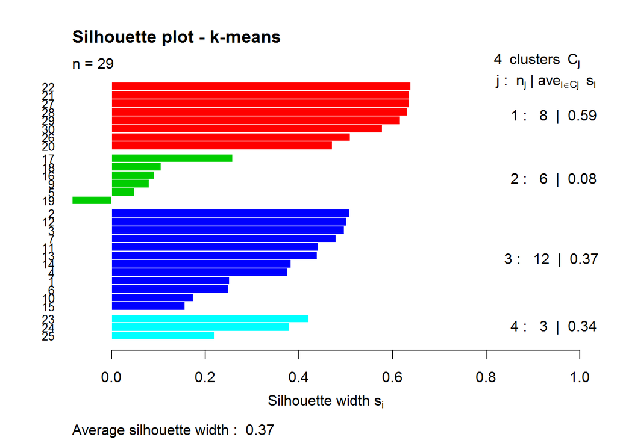

```r
# 应用 silhouette 提取轮廓信息
sil <- silhouette(spe.kmeans.g, # 聚类分析的 簇类向量
                  spe.ch) # 物种数据集的弦距离矩阵
rownames(sil) <- row.names(spe)
k <- 4

plot(sil,
     main = "Silhouette plot - k-means",
     cex.names = 0.8,
     col = 2:(k + 1)
     )
```

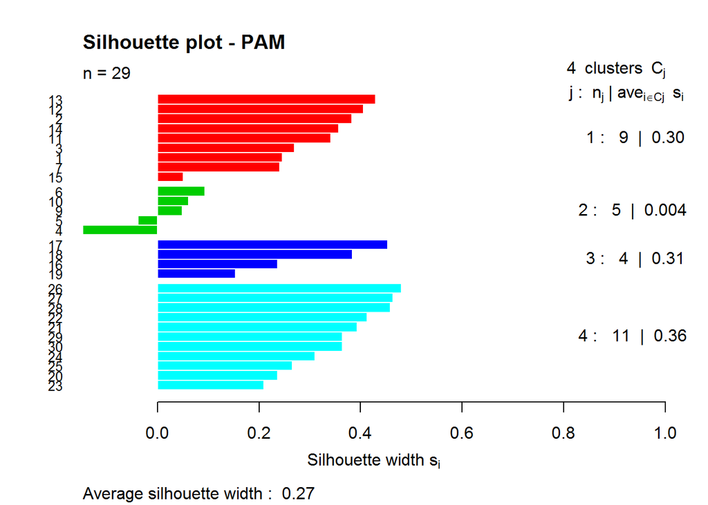

```r
plot(
  silhouette(spe.ch.pam),
  main = "Silhouette plot - PAM",
  cex.names = 0.8,
  col = 2:(k + 1)
  )
```

```r
# 通过列联表进行比较分析
# 使用交叉分类因子来构建每个因子水平组合的计数的列联表
table(spe.kmeans.g,
      spech.ward.gk)
```

```
##             spech.ward.gk
## spe.kmeans.g  1  2  3  4
##            1  0  0  8  0
##            2  0  6  0  0
##            3 12  0  0  0
##            4  0  0  0  3
```

- 由于 PAM (围绕中心点划分)是最小化相异系数的和, 而不是欧式距离的平方和, 因此 pam() 方法更加’稳健’.
- 在给定分组数量之后, PAM 方法更倾向于通过一系列初始中心点收敛至相同的解决方案. 而然, 获得的方案并不能保证是最适合研究目的的解决方案.
- 选择何种方案, 取决于哪种方法的结果可以提供更多的相关信息, 或者能够更好地被环境变量解释.

## 4.9 Comparison with Environmental Data - 比较环境数据

上文中已经使用物种丰度数据为例简单介绍了多种聚类方法. 多种方法也可以应用于其他类型的数据, 尤其是环境数据表. 使用过程中一定要格外注意每个变量正确编码的选择和数据转换以及关联测度.

### 4.9.1 Comparing a Typology with External Data (ANOVA Approach) - 比较类型学与外部数据（方差分析）

通过前文中的描述, 可得知内部准则(比如仅仅依赖物种数量的轮廓宽度和其他聚类质量指标)并不总是能够选择位点的分区结果. **拓扑学的最终选择应该基于分类组的环境可解释性.** 这可以看做是位点类型学的外部验证.

可以通过判别分析(discriminant analysis)将聚类结果(通常被视为响应数据)与外部独立性数据结合, 进而进行分析. 从另一个角度看, 从社区组成型数据中获得的聚类可以被看做是方差分析意义上的一个因素或者分类标准.

本章将对几个环境变量分别进行方差分析假设(残差正态性和方差齐性, normality of residuals and homogeneity of variances)的快速评估, 分析过程中或使用带参数的方差分析, 或者使用非参数的 Kruskal-Wallis 检验.

通过使用箱式图来展示优化的 ward 聚类簇.

值得注意的是, 基于群落物种组成数据的聚类结果在方差分析中扮演一种解释变量的角色(因子角色), 但在生态学角度看来, 真正寻找的是成组位点中的环境解释.

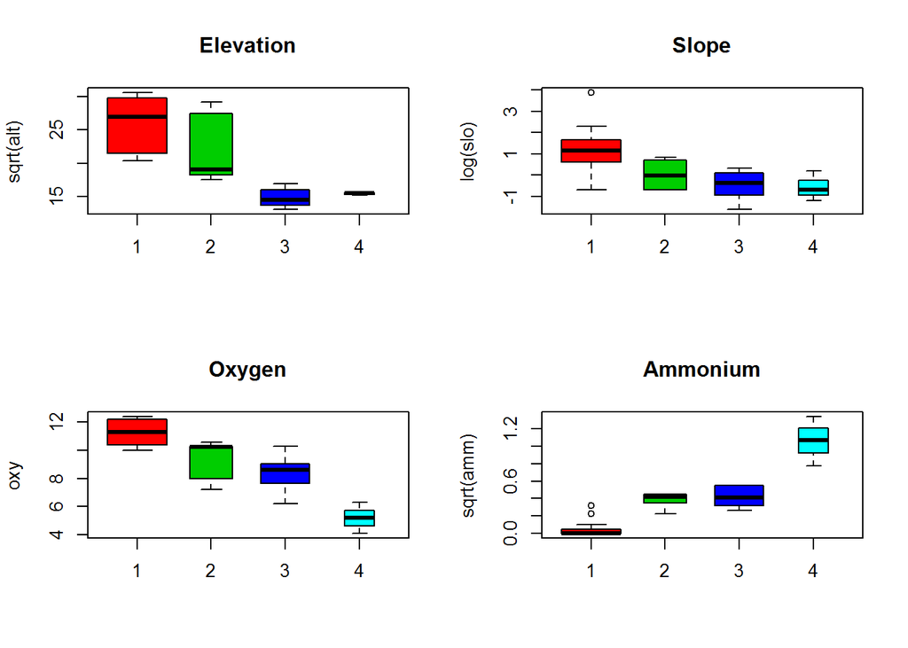

```r
# 展示鱼类数据聚类结果(基于最优分区)与环境变量之间的相关关系

# 针对特定数据框进行分析 | with() 避免重复使用数据对象
with(env, {
  # 箱式图 - 环境因子
  par(mfrow = c(2, 2))
  boxplot(
    sqrt(ele) ~ spech.ward.gk, # 映射关系 y - sqrt(ele); x - spech.ward.gk
    main = "Elevation",
    ylab = "sqrt(alt)",
    col = (1:k) + 1,
    varwidth = TRUE) # 框宽度与组中观察数的平方根成比例
  boxplot(
    log(slo) ~ spech.ward.gk,
    main = "Slope",
    ylab = "log(slo)",
    col = (1:k) + 1,
    varwidth = TRUE)
  boxplot(
    oxy ~ spech.ward.gk,
    main = "Oxygen",
    ylab = "oxy",
    col = (1:k) + 1,
    varwidth = TRUE )
  boxplot(
    sqrt(amm) ~ spech.ward.gk,
    main = "Ammonium",
    ylab = "sqrt(amm)",
    col = (1:k) + 1,
    varwidth = TRUE) # 框宽度与组中观察数的平方根成比例
  })
```

```r
# 针对特定数据框进行分析
with(env, {
  # 方差分析假设检验 - Test of ANOVA assumptions

  # Normality of residuals - 残差正态性
  shapiro.test(resid(aov(sqrt(ele) ~ as.factor(spech.ward.gk))))
  shapiro.test(resid(aov(log(slo) ~ as.factor(spech.ward.gk))))
  shapiro.test(resid(aov(oxy ~ as.factor(spech.ward.gk))))
  shapiro.test(resid(aov(sqrt(amm) ~ as.factor(spech.ward.gk))))

  # 残差呈正态分布, 表示测试的效力足够
  # 对其他变量尝试寻找出好的数据标准化转换.

  # Homogeneity of variances - 方差的同质性
  bartlett.test(sqrt(ele), as.factor(spech.ward.gk))
  bartlett.test(log(slo), as.factor(spech.ward.gk))
  bartlett.test(oxy, as.factor(spech.ward.gk))
  bartlett.test(sqrt(amm), as.factor(spech.ward.gk))

  # 变量 sqrt(ele) 具有异构差异, 不适合进行有参方差分析(parametric ANOVA)

  # ANOVA of the testable variables - 可测试变量的方差分析
  summary(aov(log(slo) ~ as.factor(spech.ward.gk)))
  summary(aov(oxy ~ as.factor(spech.ward.gk)))
  summary(aov(sqrt(amm) ~ as.factor(spech.ward.gk)))

  # Kruskal-Wallis test of variable alt - 变量测试
  kruskal.test(ele ~ as.factor(spech.ward.gk))
  })
```

```
##
##  Kruskal-Wallis rank sum test
##
## data:  ele by as.factor(spech.ward.gk)
## Kruskal-Wallis chi-squared = 21.526, df = 3, p-value = 8.186e-05
```

->>>>->>>>->>>>->>>>->>>>

**方差分析假设检验 - Test of ANOVA assumptions**

```r
# Normality of residuals - 残差正态性
shapiro.test(resid(aov(sqrt(env$ele) ~ as.factor(spech.ward.gk))))
```

```
##
##  Shapiro-Wilk normality test
##
## data:  resid(aov(sqrt(env$ele) ~ as.factor(spech.ward.gk)))
## W = 0.96248, p-value = 0.3778
```

```r
# Normality of residuals - 残差正态性
shapiro.test(resid(aov(log(env$slo) ~ as.factor(spech.ward.gk))))
```

```
##
##  Shapiro-Wilk normality test
##
## data:  resid(aov(log(env$slo) ~ as.factor(spech.ward.gk)))
## W = 0.95182, p-value = 0.204
```

```r
# Normality of residuals - 残差正态性
shapiro.test(resid(aov(env$oxy ~ as.factor(spech.ward.gk))))
```

```
##
##  Shapiro-Wilk normality test
##
## data:  resid(aov(env$oxy ~ as.factor(spech.ward.gk)))
## W = 0.93941, p-value = 0.09674
```

```r
# Normality of residuals - 残差正态性
shapiro.test(resid(aov(sqrt(env$amm) ~ as.factor(spech.ward.gk))))
```

```
##
##  Shapiro-Wilk normality test
##
## data:  resid(aov(sqrt(env$amm) ~ as.factor(spech.ward.gk)))
## W = 0.95398, p-value = 0.2319
```

```r
# >>>>>>>>>>>>>>>>>>>>>>>>>>>>>>>>>>>>>>>>>>
# Homogeneity of variances - 方差的同质性
bartlett.test(sqrt(env$ele), as.factor(spech.ward.gk))
```

```
##
##  Bartlett test of homogeneity of variances
##
## data:  sqrt(env$ele) and as.factor(spech.ward.gk)
## Bartlett's K-squared = 16.942, df = 3, p-value = 0.0007265
```

```r
# Homogeneity of variances - 方差的同质性
bartlett.test(log(env$slo), as.factor(spech.ward.gk))
```

```
##
##  Bartlett test of homogeneity of variances
##
## data:  log(env$slo) and as.factor(spech.ward.gk)
## Bartlett's K-squared = 2.9832, df = 3, p-value = 0.3942
```

```r
# Homogeneity of variances - 方差的同质性
bartlett.test(env$oxy, as.factor(spech.ward.gk))
```

```
##
##  Bartlett test of homogeneity of variances
##
## data:  env$oxy and as.factor(spech.ward.gk)
## Bartlett's K-squared = 1.8258, df = 3, p-value = 0.6093
```

```r
# Homogeneity of variances - 方差的同质性
bartlett.test(sqrt(env$amm), as.factor(spech.ward.gk))
```

```
##
##  Bartlett test of homogeneity of variances
##
## data:  sqrt(env$amm) and as.factor(spech.ward.gk)
## Bartlett's K-squared = 5.7203, df = 3, p-value = 0.126
```

```r
# >>>>>>>>>>>>>>>>>>>>>>>>>>>>>>>>>>>>>>>>>>
# ANOVA of the testable variables - 可测试变量的方差分析
summary(aov(log(env$slo) ~ as.factor(spech.ward.gk)))
```

```
##                          Df Sum Sq Mean Sq F value  Pr(>F)
## as.factor(spech.ward.gk)  3  18.05   6.018   7.283 0.00114 **
## Residuals                25  20.66   0.826
## ---
## Signif. codes:  0 '***' 0.001 '**' 0.01 '*' 0.05 '.' 0.1 ' ' 1
```

```r
# ANOVA of the testable variables - 可测试变量的方差分析
summary(aov(env$oxy ~ as.factor(spech.ward.gk)))
```

```
##                          Df Sum Sq Mean Sq F value   Pr(>F)
## as.factor(spech.ward.gk)  3 103.54   34.51   26.27 6.75e-08 ***
## Residuals                25  32.84    1.31
## ---
## Signif. codes:  0 '***' 0.001 '**' 0.01 '*' 0.05 '.' 0.1 ' ' 1
```

```r
# ANOVA of the testable variables - 可测试变量的方差分析
summary(aov(sqrt(env$amm) ~ as.factor(spech.ward.gk)))
```

```
##                          Df Sum Sq Mean Sq F value   Pr(>F)
## as.factor(spech.ward.gk)  3 2.6126  0.8709   49.55 1.15e-10 ***
## Residuals                25 0.4394  0.0176
## ---
## Signif. codes:  0 '***' 0.001 '**' 0.01 '*' 0.05 '.' 0.1 ' ' 1
```

```r
# >>>>>>>>>>>>>>>>>>>>>>>>>>>>>>>>>>>>>>>>>>
# Kruskal-Wallis test of variable alt - 变量测试
kruskal.test(env$ele ~ as.factor(spech.ward.gk))
```

```
##
##  Kruskal-Wallis rank sum test
##
## data:  env$ele by as.factor(spech.ward.gk)
## Kruskal-Wallis chi-squared = 21.526, df = 3, p-value = 8.186e-05
```

<<<<-<<<<-<<<<-<<<<-<<<<-

后验试验并标记分类簇的显著性. 函数 boxplert() 可以展示方差分析(ANOVA)和 LSD 检验的多重比较, 而函数 boxplerk() 用以表示 Kruskal-Wallis 检验和相对应的事后验证比较(**两者都是用 Holm 校正**)

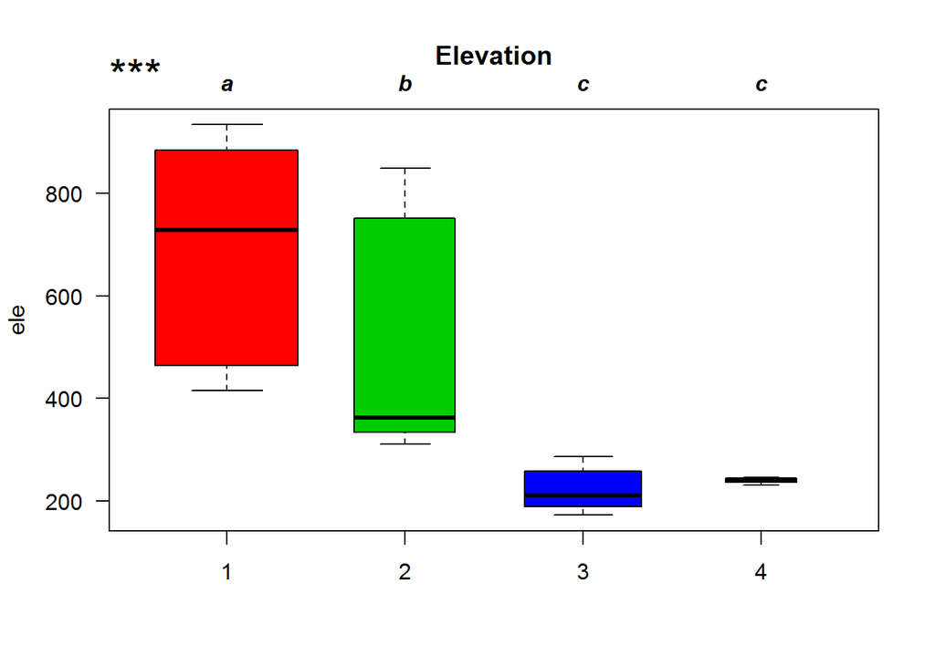

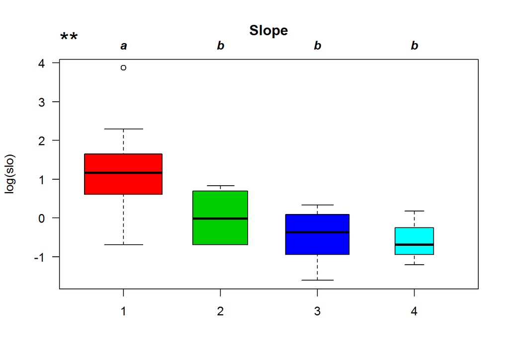

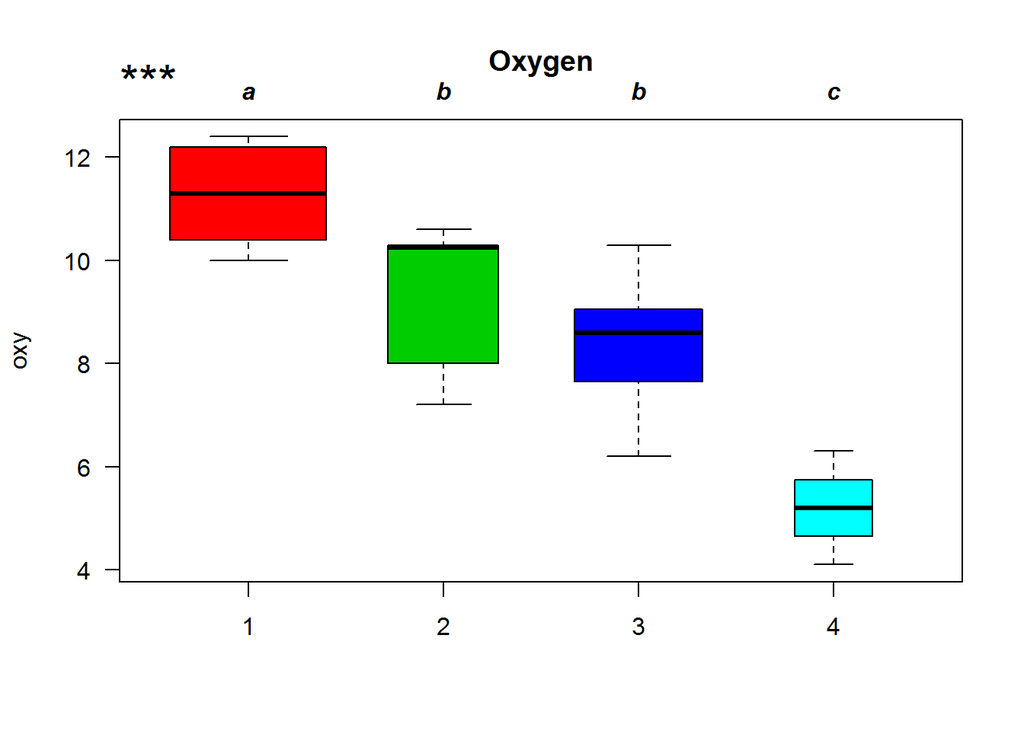

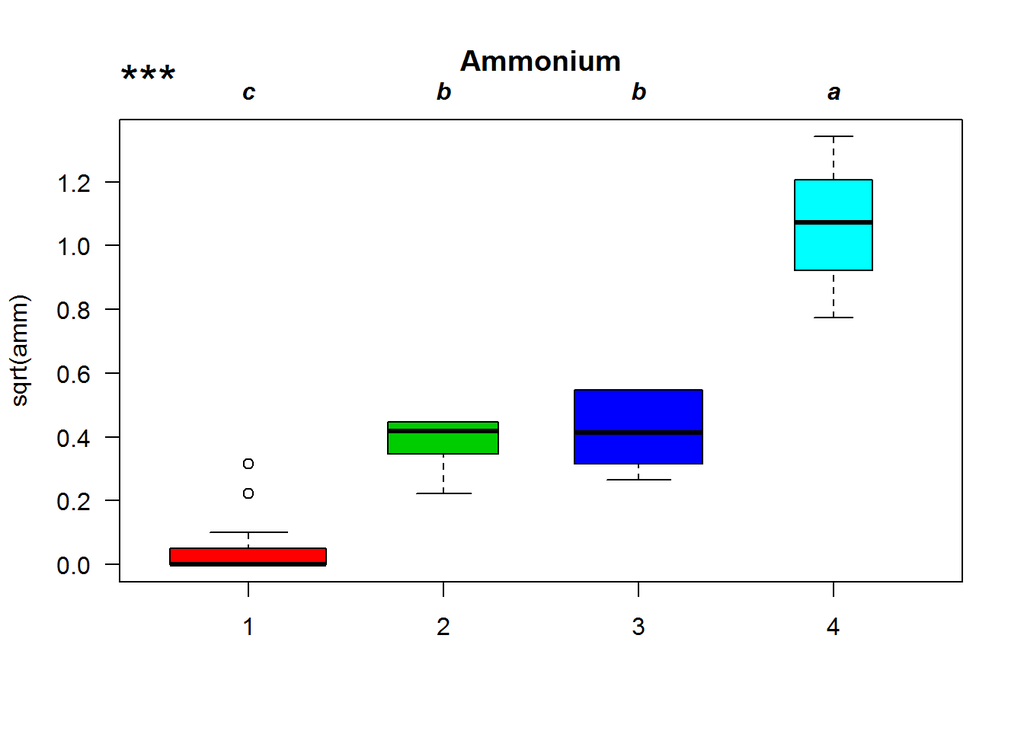

```
## $comparison
##         mean         se         sd       min       max  n group
## 1 0.05331955 0.03088153 0.10697677 0.0000000 0.3162278 12     c
## 2 0.38315935 0.03611717 0.08846863 0.2236068 0.4472136  6     b
## 3 0.42079101 0.04501576 0.12732379 0.2645751 0.5477226  8     b
## 4 1.06287266 0.16376055 0.28364160 0.7745967 1.3416408  3     a
##
## $p.value
## [1] 1.150645e-10
```

```r
# kruskal() - Kruskal Wallis Test And Multiple Comparison Of Treatments.
# 多重比较
# 事后测试是使用标准费舍尔最不显着的差异 - 调整方法包括Bonferroni校正等
# https://www.rdocumentation.org/packages/agricolae/versions/1.3-1/topics/kruskal
# p.adj - p-value 校准 c("none","holm","hommel", "hochberg", "bonferroni", "BH", "BY", "fdr")
# bcol -- boxplot 中的 col 选项
# par(mfrow = c(2, 2))
with(env, {
  # boxplert() or boxplerk() 显著性标记 - 星号 | post-hoc tests - 事后验证
  # https://github.com/zdealveindy/anadat-r/blob/master/scripts/NumEcolR2/boxplerk.R
  boxplerk( # 多重比较&带有字母的箱式图
    ele,
    spech.ward.gk,
    xlab = "",
    ylab = "ele",
    main = "Elevation",
    bcol = (1:k) + 1,
    p.adj = "holm")
  # https://github.com/zdealveindy/anadat-r/blob/master/scripts/NumEcolR2/boxplert.R
  boxplert( # 多重比较&带有字母的箱式图
    log(slo),
    spech.ward.gk,
    xlab = "",
    ylab = "log(slo)",
    main = "Slope",
    bcol = (1:k) + 1,
    p.adj = "holm")
  # https://github.com/zdealveindy/anadat-r/blob/master/scripts/NumEcolR2/boxplert.R
  boxplert(
    oxy,
    spech.ward.gk,
    xlab = "",
    ylab = "oxy",
    main = "Oxygen",
    bcol = (1:k) + 1,
    p.adj = "holm")
  # https://github.com/zdealveindy/anadat-r/blob/master/scripts/NumEcolR2/boxplert.R
  boxplert(
    sqrt(amm),
    spech.ward.gk,
    xlab = "",
    ylab = "sqrt(amm)",
    main = "Ammonium",
    bcol = (1:k) + 1,
    p.adj = "holm")
  })
```

- **在此分析的基础上, 如何确定四种鱼类群落类型的生态类型??**

当然, 也可以进行相反的分析过程. 先聚类环境变量(获取一系列的生境特征), 然后通过指示物种分析的方式检测物种是否显著响应这些栖息地类型(4.11). 在这种方法中, 物种逐一针对栖息地类型进行测试. 如果对多个物种进行独立测试, 请考虑多次测试的问题. 作为替代方案，将在第6章中提出基于排序的多变量方法，以直接模拟和测试物种 - 栖息地关系

### 4.9.2 Comparing Two Typologies (Contingency Table Approach) - 比较两种类型（列联表方法）

如果仅想简单比较由物种数据产生的类型学和由环境变量独立获得的类型学, 可以使用列联表的形式进行类型学特征的比较和使用 Fisher extract 测试.

```r
# Environment-based typology - 基于环境的类型学
env2 <- env[, -1] # 删除环境因子数据集的第 1 列
env.de <- vegdist(scale(env2), "euc") # 数据变换之后,计算 euclidean 距离的相异矩阵
env.kmeans <- kmeans(env.de, # 距离相异矩阵
                     centers = 4, # 划分成的簇数
                     nstart = 100) # 如果 centers 是整数,应该选取多少个随机数据集
env.kmeans.g <- env.kmeans$cluster

# 通过列联表进行比较分析
# 使用交叉分类因子来构建每个因子水平组合的计数的列联表
# 物种与环境交叉表 - 4组类型
table(spe.kmeans.g, env.kmeans.g)
```

```
##             env.kmeans.g
## spe.kmeans.g 1 2 3 4
##            1 0 0 3 5
##            2 0 2 4 0
##            3 1 7 4 0
##            4 2 0 0 1
```

```r
# 使用 卡方检验 相关关系
chisq.test(table(spe.kmeans.g, env.kmeans.g))
```

```
##
##  Pearson's Chi-squared test
##
## data:  table(spe.kmeans.g, env.kmeans.g)
## X-squared = 30.227, df = 9, p-value = 0.0004014
```

```r
# 卡方检验 - 检验过程更改为'置换方式'
chisq.test(table(spe.kmeans.g, env.kmeans.g), simulate.p.value = TRUE)
```

```
##
##  Pearson's Chi-squared test with simulated p-value (based on 2000
##  replicates)
##
## data:  table(spe.kmeans.g, env.kmeans.g)
## X-squared = 30.227, df = NA, p-value = 0.0004998
```

```r
# Fisher's 精确检验 相关关系
fisher.test(table(spe.kmeans.g, env.kmeans.g))
```

```
##
##  Fisher's Exact Test for Count Data
##
## data:  table(spe.kmeans.g, env.kmeans.g)
## p-value = 0.0003094
## alternative hypothesis: two.sided
```

## 4.10 Species Assemblages - 物种组合

目前有很多方法可以解决数据集中物种的关联性问题.

### 4.10.1 Simple Statistics on Group Contents - 组内数据的简单统计

先前的章节中介绍了一种定义粗放型集合的方法: 一是计算由聚类方法获得的类型学的基本统计量(例如实例平均值), 二是寻找在位点的每个聚类簇中广泛存在,高丰度或者独特的物种.

```r
# 位点聚类簇的平均物种丰度
groups <- as.factor(spech.ward.gk) # ward 聚类簇 因子化
spe.means <- matrix(0, ncol(spe), length(levels(groups))) # 全 0 矩阵
row.names(spe.means) <- colnames(spe)
for (i in 1:ncol(spe)) {
  # tapply - 将函数应用于不规则数组的每个单元格
  # 进行分组统计 - tapply(x,f,g)
  # x为向量,f为因子列,g为操作函数,相对数据框进行类似操作可以用by函数
  spe.means[i, ] <- tapply(spe[, i], spech.ward.gk, mean)
  }
# 4 簇 不同的平均物种丰度
group1 <- round(sort(spe.means[, 1], decreasing = TRUE), 2) # 保留两位小数
group2 <- round(sort(spe.means[, 2], decreasing = TRUE), 2) # 保留两位小数
group3 <- round(sort(spe.means[, 3], decreasing = TRUE), 2) # 保留两位小数
group4 <- round(sort(spe.means[, 4], decreasing = TRUE), 2) # 保留两位小数
# 物种丰度 大于 组平均物种丰度
group1.domin <- which(group1 > mean(group1))
head(group1)
```

```
## Satr Phph Babl Thth Sqce Cogo
## 4.00 4.00 3.58 1.00 1.00 0.92
```

```r
head(group1.domin)
```

```
## Satr Phph Babl Thth Sqce Cogo
##    1    2    3    4    5    6
```

```r
# 其他组 分析类同
group2.domin <- which(group2 > mean(group2))
head(group2)
```

```
## Babl Ruru Phph Lele Sqce Pato
## 3.67 3.17 2.83 2.83 2.50 2.33
```

```r
group3.domin <- which(group3 > mean(group3))
head(group3)
```

```
## Alal Ruru Gogo Gyce Titi Baba
## 5.00 4.88 4.38 4.12 4.00 3.75
```

```r
group4.domin <- which(group4 > mean(group4))
head(group4)
```

```
## Alal Sqce Ruru Gogo Gyce Chna
## 3.33 1.33 1.33 1.00 1.00 0.33
```

### 4.10.2 Kendall’s W Coefficient of Concordance - Kendall 一致性系数

**当判断的数量[=物种数量]很小时(Kendall’s 一致性系数检验应用的实际场景多是如此), 经典的卡方检验(classical χ2 test)过于保守, 而置换检验可以校正 I 型错误; 置换检验的效力因此也就更高.**

简单示例: 使用 k-均值聚类分析鱼类物种数据集, 执行全局检验(kendall.global())验证是否所有物种的分组是全局显著关联的. 如果所有物种的分组全局显著关联, 则对每个分组的物种进行后验概率检验(post hoc tests, kendall.post())进而确保组内的所有物种是否具有一致性(concordant).

```r
# https://www.rdocumentation.org/packages/vegan/versions/2.4-2/topics/decostand
spe.hel <- decostand(spe, "hellinger") # 物种数据变换 - hellinger
spe.std <- decostand(spe.hel, "standardize") # 数据变换 - 标准化
spe.t <- t(spe.std)

# 第一次 涉及所有物种的 kendall 一致性检验
(spe.kendall.global1 <- kendall.global(spe.hel)) # 直接显示全部结果
```

```
## $Concordance_analysis
##                Group.1
## W         2.085701e-01
## F         6.851929e+00
## Prob.F    7.883895e-23
## Chi2      1.576790e+02
## Prob.perm 1.000000e-03
##
## attr(,"class")
## [1] "kendall.global"
```

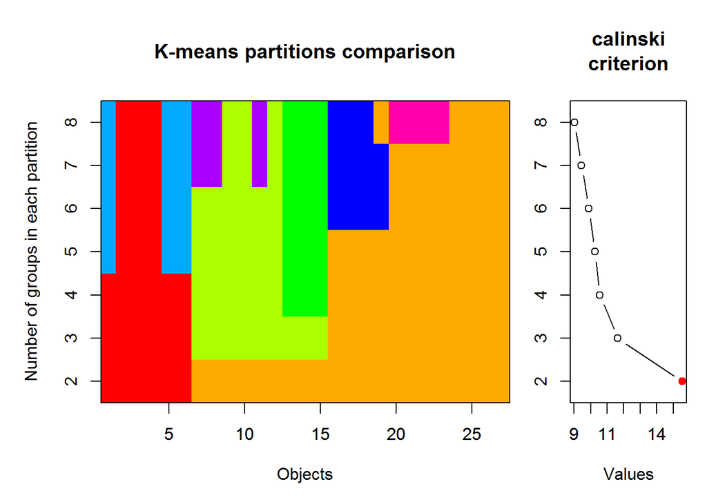

```r
# 拒绝零假设
# 寻找物种的分组, 并进行 kendall 一致性检验分析

# 物种 k-均值 分区
# cascadeKM 是 vegan 分析包中的 函数
# 使用一系列的 k 值进行k-均值划分
# https://www.rdocumentation.org/packages/vegan/versions/2.4-2/topics/cascadeKM
spe.t.kmeans.casc <- cascadeKM(
  spe.t, # 两次数据变换(hellinger -> standardize)之后的转置数据集
  inf.gr = 2,  # 最小分区个数数值
  sup.gr = 8, # 最大分区个数数值
  iter = 100, # 随机数起始的配指数
  criterion = "calinski") # 用于选择最佳分区的标准参考 | Calinski-Harabasz (1974) criterion
plot(spe.t.kmeans.casc, sortg = TRUE) # 排序绘图
```

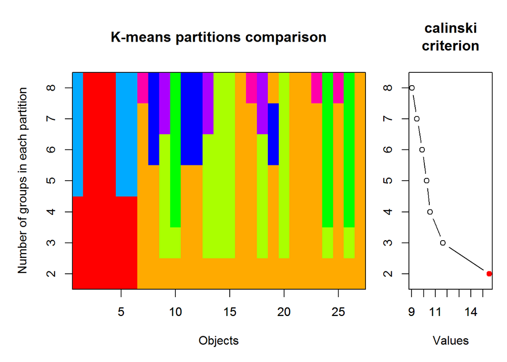

```r
plot(spe.t.kmeans.casc, sortg = F) # 不排序绘图
```

```r
plot(spe.t.kmeans.casc) # 使用默认参数绘图

# spe.t.kmeans.casc$partition 的第1,2,3列分成了 2,3,4 个簇
(clusters2 <- spe.t.kmeans.casc$partition[, 1]) # 直接显示全部结果
```

```
## Cogo Satr Phph Babl Thth Teso Chna Pato Lele Sqce Baba Albi Gogo Eslu Pefl
##    1    1    1    1    1    1    2    2    2    2    2    2    2    2    2
## Rham Legi Scer Cyca Titi Abbr Icme Gyce Ruru Blbj Alal Anan
##    2    2    2    2    2    2    2    2    2    2    2    2
```

```r
(clusters3 <- spe.t.kmeans.casc$partition[, 2]) # 直接显示全部结果
```

```
## Cogo Satr Phph Babl Thth Teso Chna Pato Lele Sqce Baba Albi Gogo Eslu Pefl
##    3    3    3    3    3    3    2    2    1    1    2    2    1    1    1
## Rham Legi Scer Cyca Titi Abbr Icme Gyce Ruru Blbj Alal Anan
##    2    2    1    2    1    2    2    2    1    2    1    2
```

```r
(clusters4 <- spe.t.kmeans.casc$partition[, 3]) # 直接显示全部结果
```

```
## Cogo Satr Phph Babl Thth Teso Chna Pato Lele Sqce Baba Albi Gogo Eslu Pefl
##    3    3    3    3    3    3    2    2    1    4    2    2    1    1    1
## Rham Legi Scer Cyca Titi Abbr Icme Gyce Ruru Blbj Alal Anan
##    2    2    1    2    1    2    2    2    4    2    4    2
```

```r
# 重新检验两组的划分

# 一致性
# https://www.rdocumentation.org/packages/vegan/versions/2.4-2/topics/kendall.global
# 通过置换检验,测试变量或物种之间的一致性系数
(spe.kendall.global2 <- kendall.global(spe.hel, # 定量或者半定量数据框或者矩阵 | 物种数据变换 - hellinger
                                       clusters2) # 确定分组的向量
  ) # 直接显示全部结果
```

```
## $Concordance_analysis
##                          Group.1      Group.2
## W                   5.447483e-01 4.868560e-01
## F                   5.982935e+00 1.897541e+01
## Prob.F              3.784728e-13 1.552232e-63
## Corrected prob.F    3.784728e-13 3.104463e-63
## Chi2                9.151771e+01 2.862713e+02
## Prob.perm           1.000000e-03 1.000000e-03
## Corrected prob.perm 2.000000e-03 2.000000e-03
##
## $Correction.type
## [1] "holm"
##
## attr(,"class")
## [1] "kendall.global"
```

```r
# 注意校正之后的置换 p-值, 如果小于等于 0.05, 则认为所有的分组具有全局的显著性, 也就认为分组中所包含的物种是一致性的.
# 但是, 这并不意味着在全局显著性的分组中的所有物种都是一致性的, 仅仅只有一小部分是一致性的.
# 如果, 一些分组的校正 p-value 没有显著性, 也就是说这些分组中包含非一致性的物种, 同时应该更加细致地划分至更小的分组.

# 后验试验 - 计算稍慢 | 鉴定每个分组内显著性一致的物种
# https://www.rdocumentation.org/packages/vegan/versions/2.4-2/topics/kendall.global
(spe.kendall.post2 <-
     kendall.post(spe.hel, # 定量或者半定量数据框或者矩阵 | 物种数据变换 - hellinger
                  clusters2, # 确定分组的向量
                  nperm = 9999) # 置换试验的次数
  ) # 直接显示全部结果
```

```
## $A_posteriori_tests_Group
## $A_posteriori_tests_Group[[1]]
##                     Cogo      Satr      Phph      Babl      Thth      Teso
## Spearman.mean  0.5260273 0.4574273 0.5260904 0.4052419 0.4797137 0.3436127
## W.per.species  0.6050227 0.5478561 0.6050754 0.5043683 0.5664281 0.4530106
## Prob           0.0002000 0.0003000 0.0001000 0.0019000 0.0003000 0.0091000
## Corrected prob 0.0027000 0.0030000 0.0027000 0.0095000 0.0030000 0.0273000
##
## $A_posteriori_tests_Group[[2]]
##                     Chna      Pato      Lele        Sqce      Baba
## Spearman.mean  0.5617595 0.4834904 0.2155823 -0.10524823 0.5076159
## W.per.species  0.5826281 0.5080861 0.2529355 -0.05261736 0.5310627
## Prob           0.0001000 0.0001000 0.0609000  0.76620000 0.0004000
## Corrected prob 0.0027000 0.0027000 0.1218000  0.76620000 0.0032000
##                     Albi      Gogo      Eslu      Pefl      Rham      Legi
## Spearman.mean  0.5528082 0.4811296 0.3456084 0.4508612 0.6195404 0.5959256
## W.per.species  0.5741031 0.5058377 0.3767699 0.4770107 0.6376575 0.6151672
## Prob           0.0001000 0.0001000 0.0035000 0.0002000 0.0001000 0.0001000
## Corrected prob 0.0027000 0.0027000 0.0140000 0.0027000 0.0027000 0.0027000
##                     Scer      Cyca      Titi      Abbr      Icme      Gyce
## Spearman.mean  0.5177403 0.6088047 0.4416154 0.5888645 0.5117604 0.5514746
## W.per.species  0.5407051 0.6274331 0.4682052 0.6084424 0.5350099 0.5728329
## Prob           0.0001000 0.0001000 0.0004000 0.0001000 0.0001000 0.0001000
## Corrected prob 0.0027000 0.0027000 0.0032000 0.0027000 0.0027000 0.0027000
##                     Ruru      Blbj      Alal      Anan
## Spearman.mean  0.3940991 0.5606592 0.4825296 0.6237921
## W.per.species  0.4229515 0.5815801 0.5071711 0.6417067
## Prob           0.0014000 0.0001000 0.0001000 0.0001000
## Corrected prob 0.0084000 0.0027000 0.0027000 0.0027000
##
##
## $Correction.type
## [1] "holm"
##
## attr(,"class")
## [1] "kendall.post"
```

```r
# 查看每个独立物种的平均 Spearman 相关系数
# 如果每个物种与分组内的其他物种具有正平均相关性, 那么该分组中就含有一致性物种.
# 如果物种与分组内的其他成员具有负平均相关性, 则将该物种从该分组中剔除.
# 尝试更加细致的划分, 以期同组内的物种成员具有正平均相关性. 这种情况下很可能造成单一物种构成单一分组.

# 后验试验 - 计算稍慢 | 鉴定每个分组内显著性一致的物种
# https://www.rdocumentation.org/packages/vegan/versions/2.4-2/topics/kendall.global
(spe.kendall.post3 <-
     kendall.post(spe.hel, # 定量或者半定量数据框或者矩阵 | 物种数据变换 - hellinger
                  clusters3, # 确定分组的向量
                  nperm = 9999) # 置换试验的次数
  ) # 直接显示全部结果
```

```
## $A_posteriori_tests_Group
## $A_posteriori_tests_Group[[1]]
##                     Lele       Sqce     Gogo      Eslu      Pefl      Scer
## Spearman.mean  0.2811914 0.04886207 0.456994 0.3572055 0.3742885 0.4661829
## W.per.species  0.3610590 0.15454406 0.517328 0.4286271 0.4438120 0.5254959
## Prob           0.0122000 0.36280000 0.000100 0.0013000 0.0006000 0.0001000
## Corrected prob 0.0315000 0.36280000 0.002700 0.0078000 0.0042000 0.0027000
##                     Titi      Ruru      Alal
## Spearman.mean  0.4210645 0.4178715 0.3381858
## W.per.species  0.4853907 0.4825524 0.4117207
## Prob           0.0002000 0.0001000 0.0023000
## Corrected prob 0.0027000 0.0027000 0.0095000
##
## $A_posteriori_tests_Group[[2]]
##                     Chna      Pato      Baba      Albi      Rham     Legi
## Spearman.mean  0.7213995 0.6347447 0.6618451 0.7272716 0.8087863 0.778132
## W.per.species  0.7446162 0.6651827 0.6900247 0.7499989 0.8247208 0.796621
## Prob           0.0001000 0.0001000 0.0001000 0.0001000 0.0001000 0.000100
## Corrected prob 0.0027000 0.0027000 0.0027000 0.0027000 0.0027000 0.002700
##                     Cyca      Abbr      Icme      Gyce      Blbj      Anan
## Spearman.mean  0.8021848 0.7524176 0.6696215 0.6518496 0.7185266 0.8137954
## W.per.species  0.8186694 0.7730494 0.6971530 0.6808621 0.7419827 0.8293124
## Prob           0.0001000 0.0001000 0.0001000 0.0001000 0.0001000 0.0001000
## Corrected prob 0.0027000 0.0027000 0.0027000 0.0027000 0.0027000 0.0027000
##
## $A_posteriori_tests_Group[[3]]
##                     Cogo      Satr      Phph      Babl      Thth      Teso
## Spearman.mean  0.5260273 0.4574273 0.5260904 0.4052419 0.4797137 0.3436127
## W.per.species  0.6050227 0.5478561 0.6050754 0.5043683 0.5664281 0.4530106
## Prob           0.0001000 0.0005000 0.0001000 0.0019000 0.0003000 0.0105000
## Corrected prob 0.0027000 0.0040000 0.0027000 0.0095000 0.0027000 0.0315000
##
##
## $Correction.type
## [1] "holm"
##
## attr(,"class")
## [1] "kendall.post"
```

在生态关系中, 生态学理论克预测出嵌套结构. 在群落中, 物种的亚组要么紧密关联要么毫不相干. 可以通过 Kendall W 检验揭示大量物种关联中的少量物种分组来探索这些途径.

这里所定义的物种的分组可以通过多种不同的方式进行生态学解释. 比如, 绘制物种沿河流的丰度图, 并统计位点的物种组合, 可以帮助评估物种的生态作用. 另一种解释方法, 根据一组解释性环境变量计算显著关联物种的冗余分析( redundancy analysis, RDA ).